# Homework 10

Farouk Alghazzy

## Problem 1) Quantitative and Categorical Predictors (8 points)

(This problem is based on a plot from [The behavior of different clays subjected to a fast-drying cycle for traditional ceramic manufacturing](https://doi.org/10.1016/j.jksues.2022.05.003), but the data has been simulated)

An experiment was conducted on three types of **material**: Plastic clay, Sandy clay and claystone. The **plastic deformation** (%) was measured at various **moisture** (%) levels. Data is found in the `clay_sample.csv` file. Plastic deformation is denoted `pd` in the dataset.

```r
clay_data = read.csv("C:/Users/algha/OneDrive/Desktop/School/stat340/hw10/clay_sample.csv")
```

### a) Fit the model (4 points)

Create a linear model model predicting plastic deformation from moisture. Include material and the interaction between material and moisture.

```r
model = lm(pd ~ moisture * material, data = clay_data)
```

a.i. Output the standard model summary using `summary()`.

```r
summary(model)
```

```
##
## Call:
## lm(formula = pd ~ moisture * material, data = clay_data)
##
## Residuals:
##     Min      1Q  Median      3Q     Max
## -8.2343 -2.9072 -0.4121  2.6426  7.8457
##
## Coefficients:
##                                Estimate Std. Error t value Pr(>|t|)
## (Intercept)                   -103.1666    11.6696  -8.841 1.07e-12 ***
## moisture                         7.7928     0.7454  10.455 1.77e-15 ***
## materialplastic clay            23.9557    13.2986   1.801 0.076355 .
## materialsandy clay              29.2029    17.7493   1.645 0.104810
## moisture:materialplastic clay   -3.5950     0.7907  -4.547 2.48e-05 ***
## moisture:materialsandy clay     -3.5036     0.9388  -3.732 0.000406 ***
## ---
## Signif. codes:  0 '***' 0.001 '**' 0.01 '*' 0.05 '.' 0.1 ' ' 1
##
## Residual standard error: 4.122 on 64 degrees of freedom
## Multiple R-squared:  0.8776, Adjusted R-squared:  0.868
## F-statistic: 91.77 on 5 and 64 DF,  p-value: < 2.2e-16
```

a.ii. Interpret the $R^2$ statistic value in one sentence. The R^2 value of .8776 indicates that approximately 87.76% of the variability in pd is explained by the model, which includes moisture, material type, and their interaction.

a.iii. Which material represents the baseline? Claystone

a.iv. Explain how the residual standard error degrees of freedom is related to sample size and the model size. Higher DF residual means the denominator in the RSE formulas increases, which reduces RSE, also meaning a larger sample size. A smaller residual means larger model size.

### c) Interpret coefficient 2 (1 pt)

Provide an interpretation for the value of the coefficient of one of the materials, and comment on its significance. Plastic clay estimate is 23.9557 meaning that if moisture is held constant, the difference between Plastic clay and claystone is 23.9557. This p value is .076355 > .05 so it is not statistically significant

### d) Interpret coefficient 3 (1 pt)

Provide an interpretation for the value of the coefficient of one of the interaction terms, and comment on its significance. materialplastic clay has an estimate of -3.5950 meaning the slope of the regression line for moisture decreases by 3.595 units when the material is Plastic clay

### e) Assess assumptions (1 pt)

Finally display the first two diagnostic plots using `plot(<YOUR MODEL>, which=1:2)` and discuss three of the assumptions of the linear model: normality of error term, linearity and the relationship, and constant variance of the error term. You do not have to do any more modeling after this step, but comment about what you *might* want to do to improve the model.

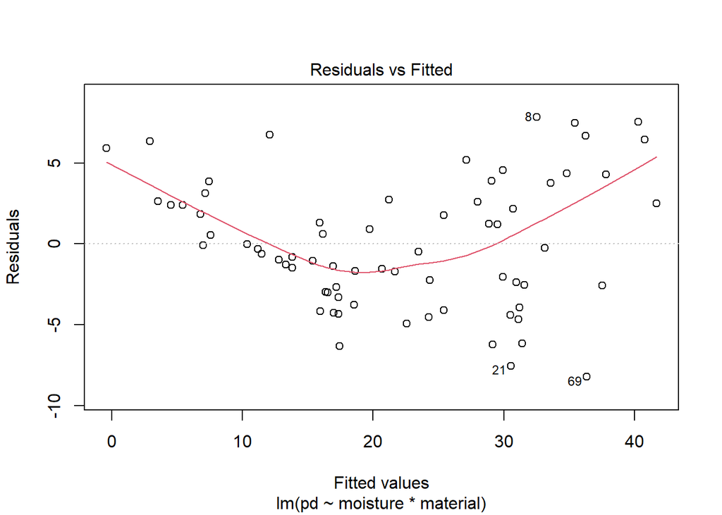

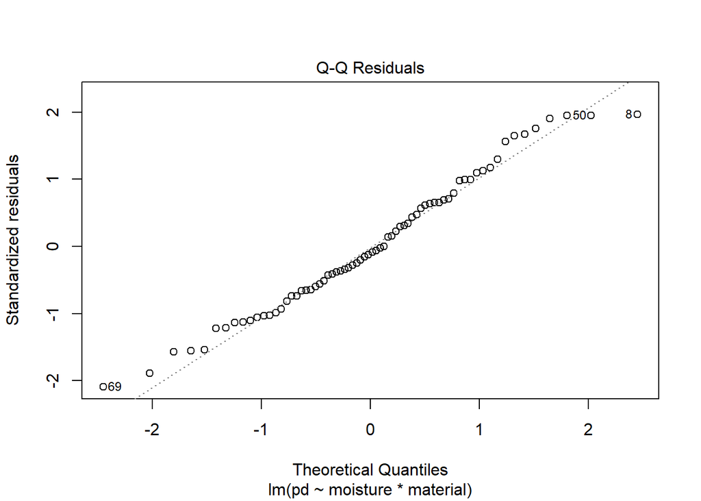

```r
plot(model, which = 1:2)
```

## Problem 2) Using Multiple regression to fit nonlinear data (8 points; 2 pt each)

Open the dataset `multData.csv`. This data set consists of three predictor variables, simply named `X1`, `X2` and `X3`. The response variable is `Y`. In this problem you will explore how to use the multiple regression model to model nonlinear relationships.

```r
multdata = read.csv("C:/Users/algha/OneDrive/Desktop/School/stat340/hw10/multData.csv")
```

### a) the first model

First we will explore the relationship between $Y$ and the first two predictors $X1$ and $X2$. Fit the linear model

$$Y = /beta_0 + \beta_1 X_1 + \beta_2 X_2
+ \epsilon$$
Interpret the coefficients of both X1 and X2.

```r
model1 = lm(Y ~ X1 + X2, data = multdata)
summary(model1)
```

```
##
## Call:
## lm(formula = Y ~ X1 + X2, data = multdata)
##
## Residuals:
##      Min       1Q   Median       3Q      Max
## -19.8649  -7.1965   0.2892   6.7130  20.5860
##
## Coefficients:
##             Estimate Std. Error t value Pr(>|t|)
## (Intercept) 948.5316    75.3339   12.59  < 2e-16 ***
## X1          -12.6318     0.2439  -51.78  < 2e-16 ***
## X2          -35.1420     4.8472   -7.25 3.42e-09 ***
## ---
## Signif. codes:  0 '***' 0.001 '**' 0.01 '*' 0.05 '.' 0.1 ' ' 1
##
## Residual standard error: 10.29 on 47 degrees of freedom
## Multiple R-squared:  0.9831, Adjusted R-squared:  0.9824
## F-statistic:  1371 on 2 and 47 DF,  p-value: < 2.2e-16
```

X1 coeff is -12.6318. Which means X1 had an effect of -12.6318 on Y when x2 is constant x2 coeff is -35.1420 which means that X2 had an effect of -35.1420 on Y when X1 is constant

### b) Investigating interaction of quantitative predictors

Next introduce an interaction term to the model
$$Y = \beta_0 + \beta_1 X_1 + \beta_2 X_2 + \beta_3
X_1\cdot X_2 + \epsilon$$

Fit the model and view the summary output. Has this improved the model fit? Did anything surprising happen to the coefficients? Try to explain what happened.

```r
model2 = lm(Y ~ X1 * X2, data = multdata)
summary(model2)
```

```
##
## Call:
## lm(formula = Y ~ X1 * X2, data = multdata)
##
## Residuals:
##      Min       1Q   Median       3Q      Max
## -18.9683  -6.4850   0.3495   7.5219  16.6880
##
## Coefficients:
##             Estimate Std. Error t value Pr(>|t|)
## (Intercept) 298.9182   239.2336   1.249  0.21781
## X1           19.0469    11.1545   1.708  0.09446 .
## X2            6.7768    15.4337   0.439  0.66265
## X1:X2        -2.0441     0.7196  -2.841  0.00669 **
## ---
## Signif. codes:  0 '***' 0.001 '**' 0.01 '*' 0.05 '.' 0.1 ' ' 1
##
## Residual standard error: 9.589 on 46 degrees of freedom
## Multiple R-squared:  0.9857, Adjusted R-squared:  0.9847
## F-statistic:  1054 on 3 and 46 DF,  p-value: < 2.2e-16
```

### c) Introducing the last predictor

Next fit a model that introduces the `X3` variable.

$$Y = \beta_0 + \beta_1 X_1 + \beta_2 X_2
+ \beta_3 X_1\cdot X_2 + \beta_4 X_3 \epsilon$$
Has the model fit improved? In what way (Justify your answer)?

```r
model3 = lm(Y ~ X1 * X2 + X3, data = multdata)
summary(model3)
```

```
##
## Call:
## lm(formula = Y ~ X1 * X2 + X3, data = multdata)
##
## Residuals:
##      Min       1Q   Median       3Q      Max
## -1.91799 -0.66205 -0.09031  0.67703  2.12326
##
## Coefficients:
##              Estimate Std. Error t value Pr(>|t|)
## (Intercept) 101.56434   25.91680   3.919    3e-04 ***
## X1           26.14504    1.20478  21.701  < 2e-16 ***
## X2           19.91029    1.67276  11.903 1.69e-15 ***
## X3           95.43888    1.52178  62.715  < 2e-16 ***
## X1:X2        -2.51881    0.07775 -32.397  < 2e-16 ***
## ---
## Signif. codes:  0 '***' 0.001 '**' 0.01 '*' 0.05 '.' 0.1 ' ' 1
##
## Residual standard error: 1.031 on 45 degrees of freedom
## Multiple R-squared:  0.9998, Adjusted R-squared:  0.9998
## F-statistic: 6.935e+04 on 4 and 45 DF,  p-value: < 2.2e-16
```

This a better fit because the R^2 value is much higher at .9998

### d) Considering higher order terms

Finally explore higher order terms for the X3 variable: Introduce $X_3^2$, $X_3^3$ etc and determine if any of these higher order terms are justified in the model. Explain your reasoning and present your final model. Look at the diagnostic plots and discuss whether the assumptions of the multiple regression model seem to be justified.

```r
model4 = lm(Y ~ X1 * X2 + poly(X3, 1, raw = TRUE), data = multdata)
summary(model4)
```

```
##
## Call:
## lm(formula = Y ~ X1 * X2 + poly(X3, 1, raw = TRUE), data = multdata)
##
## Residuals:
##      Min       1Q   Median       3Q      Max
## -1.91799 -0.66205 -0.09031  0.67703  2.12326
##
## Coefficients:
##                          Estimate Std. Error t value Pr(>|t|)
## (Intercept)             101.56434   25.91680   3.919    3e-04 ***
## X1                       26.14504    1.20478  21.701  < 2e-16 ***
## X2                       19.91029    1.67276  11.903 1.69e-15 ***
## poly(X3, 1, raw = TRUE)  95.43888    1.52178  62.715  < 2e-16 ***
## X1:X2                    -2.51881    0.07775 -32.397  < 2e-16 ***
## ---
## Signif. codes:  0 '***' 0.001 '**' 0.01 '*' 0.05 '.' 0.1 ' ' 1
##
## Residual standard error: 1.031 on 45 degrees of freedom
## Multiple R-squared:  0.9998, Adjusted R-squared:  0.9998
## F-statistic: 6.935e+04 on 4 and 45 DF,  p-value: < 2.2e-16
```

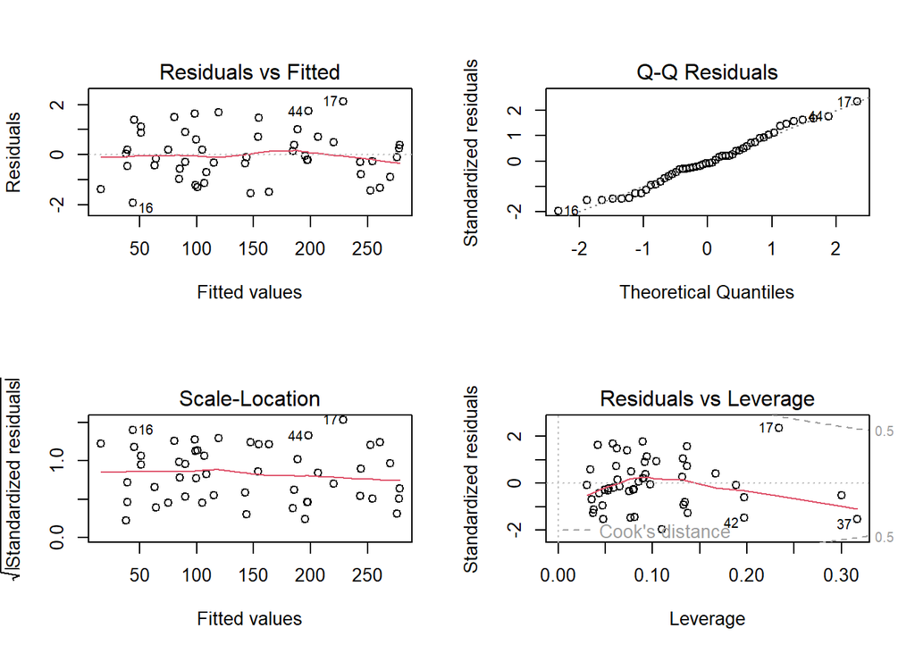

```r
par(mfrow = c(2, 2))
plot(model4)
```

## Problem 3) Blood Pressure Data (8 points, 2 pts each)

Some researchers observed the following data (`bloodpress.txt`) on 20 individuals with high blood pressure:

- blood pressure (y = BP, in mm Hg)
- age (x1 = Age, in years)
- weight (x2 = Weight, in kg)
- body surface area (x3 = BSA, in sq m)
- duration of hypertension (x4 = Dur, in years)
- basal pulse (x5 = Pulse, in beats per minute)
- stress index (x6 = Stress)

The researchers were interested in determining if a relationship exists between blood pressure and age, weight, body surface area, duration, pulse rate and/or stress level. *Note: You can use `read.table()` to read .txt datafiles into R.

```r
bp_data = read.table("bloodpress.txt", header = TRUE)
```

1. Which predictor variables are most strongly correlated with BP? Give the top 3 predictors and their sample correlation coefficient’s (Pearson’s r).

```r
correlations = cor(bp_data)

bp_corrs = correlations["BP", -which(colnames(correlations) == "BP")]

top3 = sort(abs(bp_corrs), decreasing = TRUE)[1:3]
top3
```

```
##    Weight       BSA     Pulse
## 0.9500677 0.8658789 0.7214132
```

1. Weight: r = 0.9501
2. BSA: r = .8659
3. Pulse: r = .7214
2. Fit a linear model predicting blood pressure from two predictors: `BSA` and `Weight`. State the coefficients and provide a 1 sentence interpretation for the coefficient of BSA

```r
model_bw = lm(BP ~ BSA + Weight, data = bp_data)
summary(model_bw)
```

```
##
## Call:
## lm(formula = BP ~ BSA + Weight, data = bp_data)
##
## Residuals:
##     Min      1Q  Median      3Q     Max
## -1.8932 -1.1961 -0.4061  1.0764  4.7524
##
## Coefficients:
##             Estimate Std. Error t value Pr(>|t|)
## (Intercept)   5.6534     9.3925   0.602    0.555
## BSA           5.8313     6.0627   0.962    0.350
## Weight        1.0387     0.1927   5.392 4.87e-05 ***
## ---
## Signif. codes:  0 '***' 0.001 '**' 0.01 '*' 0.05 '.' 0.1 ' ' 1
##
## Residual standard error: 1.744 on 17 degrees of freedom
## Multiple R-squared:  0.9077, Adjusted R-squared:  0.8968
## F-statistic: 83.54 on 2 and 17 DF,  p-value: 1.607e-09
```

For each additional square meter in BSA, blood pressure increases by approximately 5.83 mm Hg in blood pressure. This effect is not statistically significant (p = .350) c. Now fit a linear model predicting blood pressure from only `BSA`. Provide the same interpretation of the `BSA` coefficient.

```r
model_bsa = lm(BP ~ BSA, data = bp_data)
summary(model_bsa)
```

```
##
## Call:
## lm(formula = BP ~ BSA, data = bp_data)
##
## Residuals:
##    Min     1Q Median     3Q    Max
## -5.314 -1.963 -0.197  1.934  4.831
##
## Coefficients:
##             Estimate Std. Error t value Pr(>|t|)
## (Intercept)   45.183      9.392   4.811  0.00014 ***
## BSA           34.443      4.690   7.343 8.11e-07 ***
## ---
## Signif. codes:  0 '***' 0.001 '**' 0.01 '*' 0.05 '.' 0.1 ' ' 1
##
## Residual standard error: 2.79 on 18 degrees of freedom
## Multiple R-squared:  0.7497, Adjusted R-squared:  0.7358
## F-statistic: 53.93 on 1 and 18 DF,  p-value: 8.114e-07
```

## Problem 4) Transformations (6 points)

We’ll look some real estate data. The data file `duke_forest.csv` contains sale prices of 98 homes sold in Duke Fores, a neighborhood of Durham, NC in November 2020.

```r
duke_data = read.csv("C:/Users/algha/OneDrive/Desktop/School/stat340/hw10/duke_forest.csv")
```

1. (1 point) Fit a model predicting price based on area. Identify any potential problems with model assumptions using diagnostics. Also provide an interpretation of both the intercept and the slope. If not appropriate explain why.

```r
model_a = lm(price ~ area, data = duke_data)
summary(model_a)
```

```
##
## Call:
## lm(formula = price ~ area, data = duke_data)
##
## Residuals:
##     Min      1Q  Median      3Q     Max
## -802163  -70824   -3786   85449  529928
##
## Coefficients:
##              Estimate Std. Error t value Pr(>|t|)
## (Intercept) 116652.33   53302.46   2.188   0.0311 *
## area           159.48      18.17   8.777 6.29e-14 ***
## ---
## Signif. codes:  0 '***' 0.001 '**' 0.01 '*' 0.05 '.' 0.1 ' ' 1
##
## Residual standard error: 168800 on 96 degrees of freedom
## Multiple R-squared:  0.4452, Adjusted R-squared:  0.4394
## F-statistic: 77.03 on 1 and 96 DF,  p-value: 6.292e-14
```

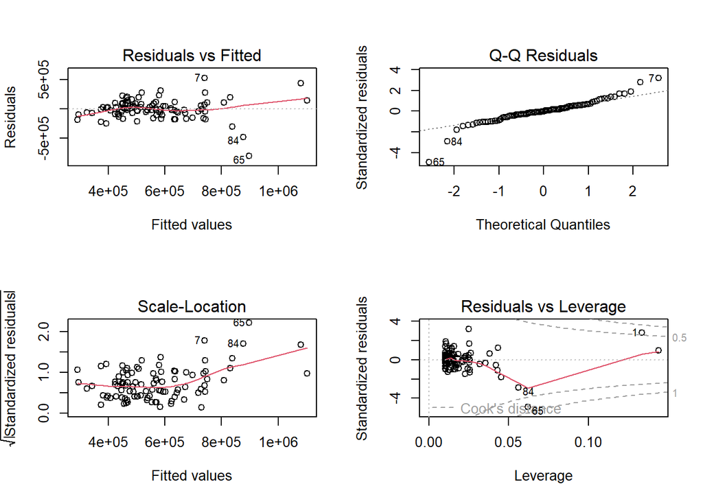

```r
par(mfrow = c(2, 2))
plot(model_a)
```

For each additional sq ft of area, the sale price increases by approximately $159.48, on average. The intercept is 116,652.33, which represents the predicted price of a home with 0 sq ft of area (since a home cannot have 0 area, this intercept is not meaningful)

2. (1 point) Now do the same thing but instead log-transform the response variable. Assess the diagnostic plots and identify if there are any problems. Also provide interpretations for the intercept and slope (again - if appropriate). If not meaningful explain wy.

```r
model_b = lm(log(price) ~ area, data = duke_data)
summary(model_b)
```

```
##
## Call:
## lm(formula = log(price) ~ area, data = duke_data)
##
## Residuals:
##      Min       1Q   Median       3Q      Max
## -2.22377 -0.09695  0.06390  0.20344  0.61847
##
## Coefficients:
##              Estimate Std. Error t value Pr(>|t|)
## (Intercept) 1.245e+01  1.191e-01 104.546  < 2e-16 ***
## area        2.531e-04  4.059e-05   6.237  1.2e-08 ***
## ---
## Signif. codes:  0 '***' 0.001 '**' 0.01 '*' 0.05 '.' 0.1 ' ' 1
##
## Residual standard error: 0.377 on 96 degrees of freedom
## Multiple R-squared:  0.2884, Adjusted R-squared:  0.281
## F-statistic:  38.9 on 1 and 96 DF,  p-value: 1.195e-08
```

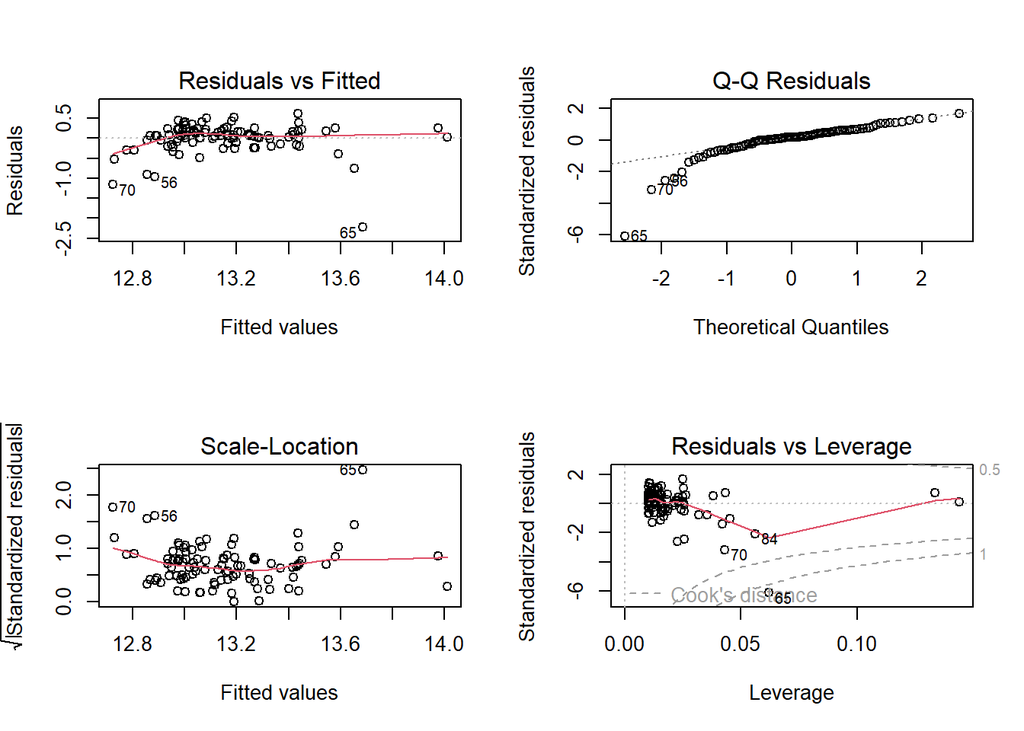

```r
par(mfrow = c(2, 2))
plot(model_b)
```

3. (1 point) Now apply a “mean centering” transformation on the area variable:
   $$area_{centered} = area -
   mean(area)$$
   Repeat the same model as in part a, but this time use centered area as the predictor. Provide an interpretation of the intercept and slope as before for this new model.

```r
duke_data$area_centered <- duke_data$area - mean(duke_data$area)
model_c <- lm(price ~ area_centered, data = duke_data)
summary(model_c)
```

```
##
## Call:
## lm(formula = price ~ area_centered, data = duke_data)
##
## Residuals:
##     Min      1Q  Median      3Q     Max
## -802163  -70824   -3786   85449  529928
##
## Coefficients:
##                Estimate Std. Error t value Pr(>|t|)
## (Intercept)   559898.67   17051.17  32.836  < 2e-16 ***
## area_centered    159.48      18.17   8.777 6.29e-14 ***
## ---
## Signif. codes:  0 '***' 0.001 '**' 0.01 '*' 0.05 '.' 0.1 ' ' 1
##
## Residual standard error: 168800 on 96 degrees of freedom
## Multiple R-squared:  0.4452, Adjusted R-squared:  0.4394
## F-statistic: 77.03 on 1 and 96 DF,  p-value: 6.292e-14
```

For each additional sq fr above the average area, the sale price increases by approximately $159.48 on average. The intercept of 559,898.67 now represents the predicted sale price of a home with average area.

4. (1 point) Summarize the pros and cons of these two transformations on the regression model. Log response: Pros — stabilizes variance and helps with skewed data. Cons — makes it harder to interpret results directly in dollar terms.

Mean centering: Pros — makes the intercept meaningful and improves interpretation in models with interactions. Cons — does not affect model fit or reduce multicollinearity by itself.

5. (2 points) Knowing everything you now know about multiple regression, try to build a good model to predict price (or a transformed version of price) from 4 of the predictor variables. Fit your model, assess the diagnostics and discuss the pros and cons of your model. What does it do well and what does it not do so well?

```r
model_e = lm(log(price) ~ area + bed + bath + year_built, data = duke_data)
summary(model_e)
```

```
##
## Call:
## lm(formula = log(price) ~ area + bed + bath + year_built, data = duke_data)
##
## Residuals:
##      Min       1Q   Median       3Q      Max
## -2.20125 -0.11081  0.03191  0.19084  0.57831
##
## Coefficients:
##              Estimate Std. Error t value Pr(>|t|)
## (Intercept) 8.621e+00  4.171e+00   2.067   0.0415 *
## area        1.436e-04  5.521e-05   2.600   0.0108 *
## bed         1.433e-02  6.498e-02   0.220   0.8260
## bath        1.436e-01  6.080e-02   2.363   0.0202 *
## year_built  1.845e-03  2.138e-03   0.863   0.3903
## ---
## Signif. codes:  0 '***' 0.001 '**' 0.01 '*' 0.05 '.' 0.1 ' ' 1
##
## Residual standard error: 0.3641 on 93 degrees of freedom
## Multiple R-squared:  0.357,  Adjusted R-squared:  0.3294
## F-statistic: 12.91 on 4 and 93 DF,  p-value: 2.118e-08
```

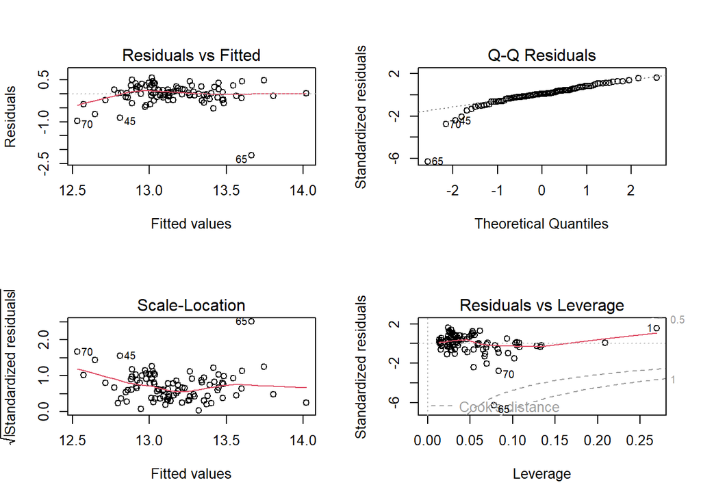

```r
par(mfrow = c(2, 2))
plot(model_e)
```

This model does a decent job explaining variability in house prices, with area and number of bathrooms as meaningful predictors. However, the predictive power is moderate, and interpretation in dollar terms is less intuitive due to the log transformation